# Task4

```r
df <- read.csv("TeachingRatings.csv");
head(df)
```

|  | X | minority | age | gender | credits | beauty | eval | division | native | tenure | students | allstudents | prof |
| --- | --- | --- | --- | --- | --- | --- | --- | --- | --- | --- | --- | --- | --- |
| 1 | 1 | yes | 36 | female | more | 0.2899157 | 4.3 | upper | yes | yes | 24 | 43 | 1 |
| 2 | 2 | no | 59 | male | more | -0.7377322 | 4.5 | upper | yes | yes | 17 | 20 | 2 |
| 3 | 3 | no | 51 | male | more | -0.5719836 | 3.7 | upper | yes | yes | 55 | 55 | 3 |
| 4 | 4 | no | 40 | female | more | -0.6779634 | 4.3 | upper | yes | yes | 40 | 46 | 4 |
| 5 | 5 | no | 31 | female | more | 1.5097940 | 4.4 | upper | yes | yes | 42 | 48 | 5 |
| 6 | 6 | no | 62 | male | more | 0.5885687 | 4.2 | upper | yes | yes | 182 | 282 | 6 |

## 3. Описание данных

В этом наборе данных есть 13 переменных:

1. X — идентификатор курса;
2. minority — принадлежит ли преподаватель к меньшинству;
3. age — возраст преподавателя;
4. gender — пол преподавателя;
5. credits — является ли предмет факультативным;
6. beauty — оценка физического облика преподавателя группой из шести студентов, усредненная по шести участникам оценки, нормированная;
7. eval — оценка преподавания курса от 1 (очень плохо) до 5 (отлично);
8. division — является ли этот курс курсом высшего или низшего отделения (Курсы низшего отделения — это в основном большие курсы первокурсников и второкурсников);
9. native — является ли преподаватель носителем английского языка;
10. tenure — имеет ли преподаватель учёную степень;
11. students — количетсво студентов, участвовавших в оценке;
12. allstudents — общее количетсво студентов, обучавшихся на этом курсе;
13. prof — идентификатор преподавателя;

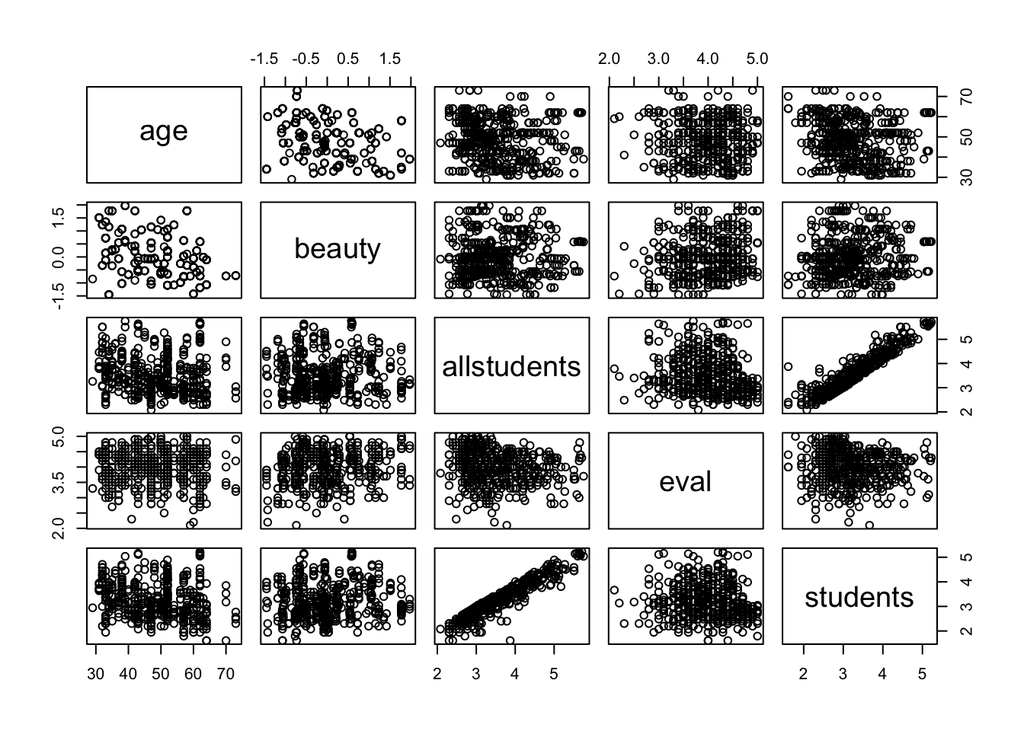

```r
#library(dplyr)
filteredData_s = df[df$prof!=73, ]
filteredData_s <- transform(filteredData_s, allstudents=log(allstudents))
filteredData_s <- transform(filteredData_s, students=log(students))
library(lattice)
panel.hist.splom <- function(x, ...) {
  h <- hist(x, plot = FALSE)
  }
pairs(~age+beauty+allstudents+eval+students,data=filteredData_s)
```

```r
length(filteredData_s$X)
```

```
## [1] 458
```

## 4.1 Линейная регрессия

Попытаемся предсказать *beauty* по *age* и *students* Модель:
$$y = b_0 + b_1 x_1 + \dots + b_p x_p +\varepsilon$$

```r
summary(lm(beauty ~ age, data = filteredData_s)) #Функция, строящая линейную регрессию. Предсказываем beauty по age В полученных результатах смотрим сначала на самую нижнюю строчку, в которой находится p-value, полученное в результате проверки гипотезы о значимости регрессии. Далее смотрим на таблицу Coefficients. В первом столбце показаны коэффициенты свободного члена (b_0) и коэффициенты перед другими предсказывающими признаками (b_1, b_2, etc). Самый правый столбец в данной таблице есть p-value, полученное в результате проверги гипотезы о том, что коэффициент перед признаком равняется нулю.
```

```
##
## Call:
## lm(formula = beauty ~ age, data = filteredData_s)
##
## Residuals:
##     Min      1Q  Median      3Q     Max
## -1.7885 -0.5579 -0.1064  0.3622  2.0183
##
## Coefficients:
##              Estimate Std. Error t value Pr(>|t|)
## (Intercept)  1.162509   0.175942   6.607 1.09e-10 ***
## age         -0.024249   0.003567  -6.799 3.32e-11 ***
## ---
## Signif. codes:  0 '***' 0.001 '**' 0.01 '*' 0.05 '.' 0.1 ' ' 1
##
## Residual standard error: 0.7512 on 456 degrees of freedom
## Multiple R-squared:  0.09204,    Adjusted R-squared:  0.09004
## F-statistic: 46.22 on 1 and 456 DF,  p-value: 3.319e-11
```

```r
summary(mdl <- lm(beauty ~ age + students, data = filteredData_s)) #Здесь все то же самое, но уже два предсказывающих признака. В данном случае, p-value проверки гипотезы о том, коэффициент перед moral равняется нулю, есть 0.02. Одна из причин, из-за которой результаты регрессии могут быть неправильными - сильно зависимые "независимые" признаки. В нашем случае moral и hetero не коррелируют, поэтому данный вариант мы отбрасываем. Далее, стоит посмотреть на аутлаеры.
```

```
##
## Call:
## lm(formula = beauty ~ age + students, data = filteredData_s)
##
## Residuals:
##     Min      1Q  Median      3Q     Max
## -1.8103 -0.5629 -0.1045  0.3914  2.0437
##
## Coefficients:
##              Estimate Std. Error t value Pr(>|t|)
## (Intercept)  1.019090   0.259365   3.929 9.85e-05 ***
## age         -0.023752   0.003629  -6.545 1.61e-10 ***
## students     0.037170   0.049369   0.753    0.452
## ---
## Signif. codes:  0 '***' 0.001 '**' 0.01 '*' 0.05 '.' 0.1 ' ' 1
##
## Residual standard error: 0.7516 on 455 degrees of freedom
## Multiple R-squared:  0.09317,    Adjusted R-squared:  0.08918
## F-statistic: 23.37 on 2 and 455 DF,  p-value: 2.176e-10
```

Глядя на этот отчёт можно сделать выводы:

1. Гипотеза о незначимости регрессии отвергается (*p-value* = 2.176e-10)
2. Гипотеза о нулевом коэффициенте при *age* отвергается (*p-value* = 1.61e-10)
3. Гипотеза о нулевом коэффициенте при *students* не отвергается (*p-value* = 0.452)

```r
# Стандартизованные коэффициенты регрессии (так называются коэффициенты регрессии, если признаки сначала стандартизовать, а потом строить регрессию). Их правильнее анализировать, так как их значение не зависит от масштаба.
library(lm.beta)
mdl2<-lm.beta(mdl)
summary(lm.beta(mdl2))
```

```
##
## Call:
## lm(formula = beauty ~ age + students, data = filteredData_s)
##
## Residuals:
##     Min      1Q  Median      3Q     Max
## -1.8103 -0.5629 -0.1045  0.3914  2.0437
##
## Coefficients:
##              Estimate Standardized Std. Error t value Pr(>|t|)
## (Intercept)  1.019090     0.000000   0.259365   3.929 9.85e-05 ***
## age         -0.023752    -3.717465   0.003629  -6.545 1.61e-10 ***
## students     0.037170     0.031438   0.049369   0.753    0.452
## ---
## Signif. codes:  0 '***' 0.001 '**' 0.01 '*' 0.05 '.' 0.1 ' ' 1
##
## Residual standard error: 0.7516 on 455 degrees of freedom
## Multiple R-squared:  0.09317,    Adjusted R-squared:  0.08918
## F-statistic: 23.37 on 2 and 455 DF,  p-value: 2.176e-10
```

Проверим остатки на нормальность

```r
library("car")
```

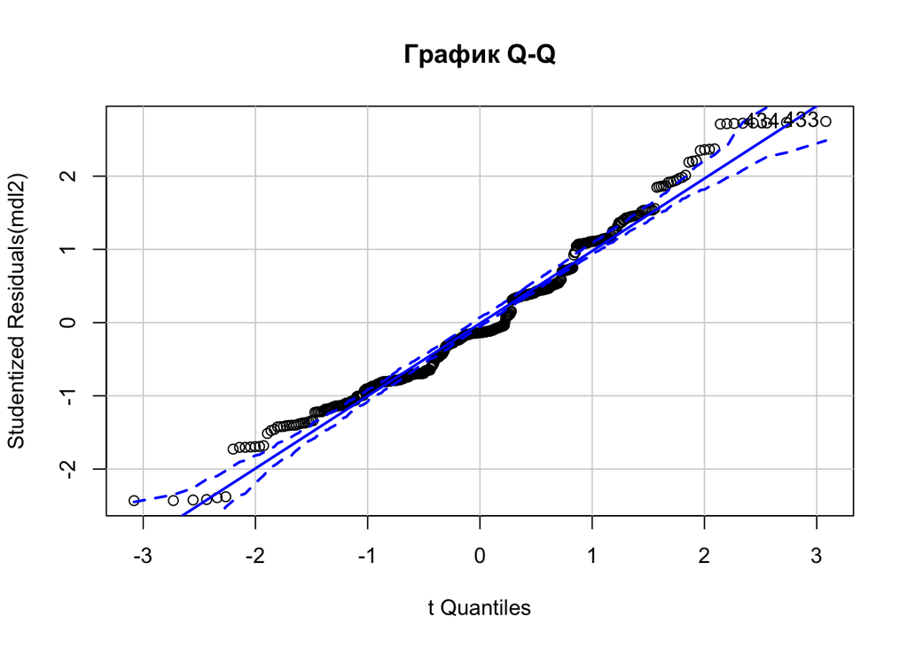

```
## 433 434
## 428 429
```

```r
##Проверяем остатки на нормальность
qqPlot(mdl2, labels = row.names(states), simulate = TRUE, main = 'График Q-Q')
```

Посмотреть на зависимость Residuals vs Predicted.

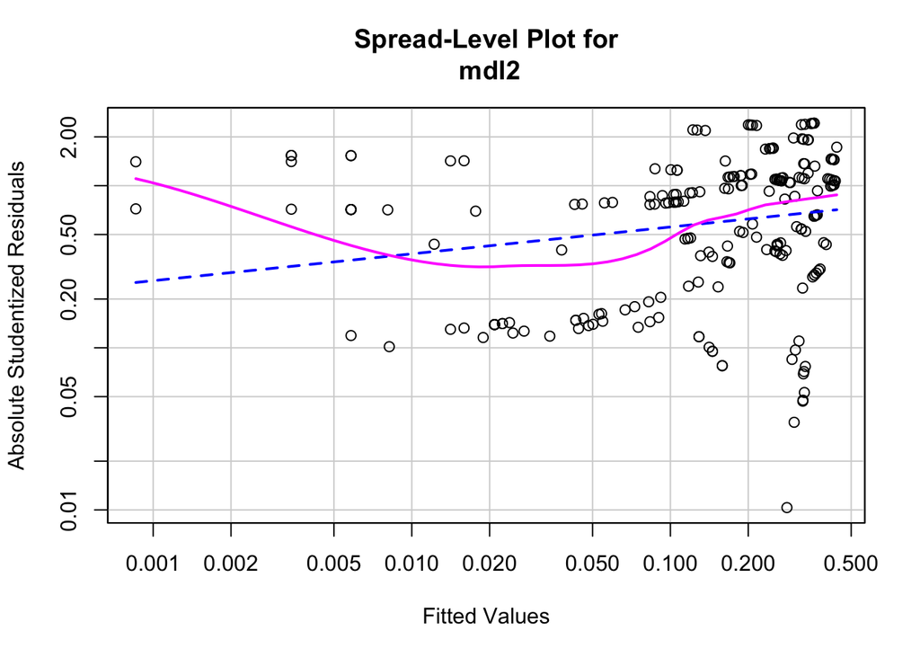

```
##
## Suggested power transformation:  0.8344371
```

```r
#Зависимость Residuals vs Predicted.
spreadLevelPlot(mdl2)
```

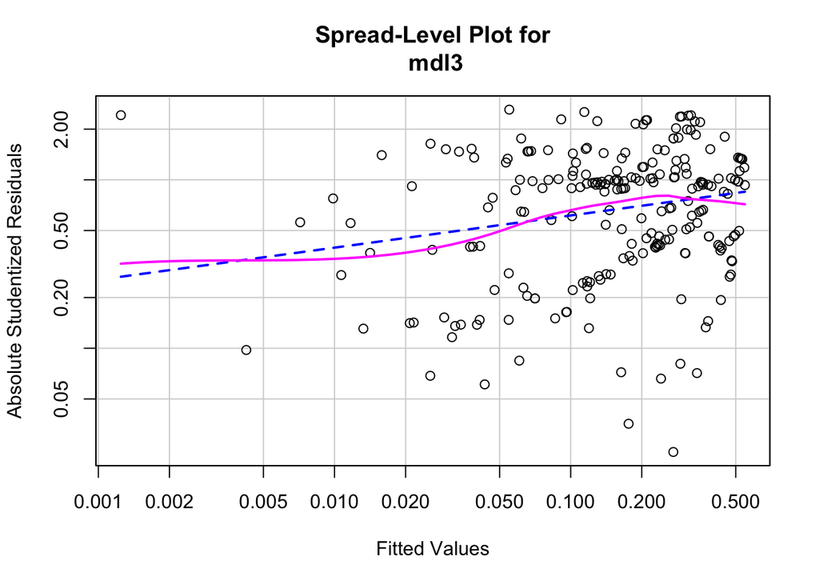

```
##
## Suggested power transformation:  0.8089389
```

```r
mdld <- lm(beauty ~ age + students + eval, data = filteredData_s)
mdl3<-lm.beta(mdld)
spreadLevelPlot(mdl3)
```

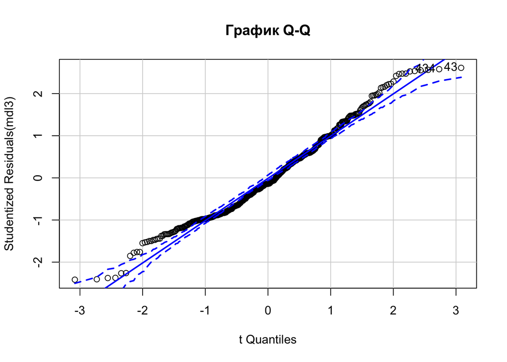

```
##  43 434
##  43 429
```

```r
qqPlot(mdl3, labels = row.names(states), simulate = TRUE, main = 'График Q-Q')
```

Видим, что присутствует гетероскедастичность, попробуем добавить, возможно, не учтённый признак

Воспользуемся AIC критерием, чтобы посмотреть можно ли сократатить количество предикторов

```r
library(MASS)
AIC(mdl3)
```

```
## [1] 1030.928
```

```r
stepAIC(mdl3) #backward
```

```
## Start:  AIC=-270.82
## beauty ~ age + students + eval
##
##            Df Sum of Sq    RSS     AIC
## - students  1    0.7385 249.90 -271.46
## <none>                  249.16 -270.82
## - eval      1    7.8617 257.02 -258.59
## - age       1   22.0762 271.24 -233.94
##
## Step:  AIC=-271.46
## beauty ~ age + eval
##
##        Df Sum of Sq    RSS     AIC
## <none>              249.90 -271.46
## - eval  1    7.4434 257.34 -260.02
## - age   1   24.4943 274.39 -230.64
```

```
##
## Call:
## lm(formula = beauty ~ age + eval, data = filteredData_s)
##
## Coefficients:
## (Intercept)          age         eval
##     0.20771     -0.02353      0.23052
```

```r
mdld2 <- lm(beauty ~ age + eval, data = filteredData_s)
mdl4<-lm.beta(mdld2)
```

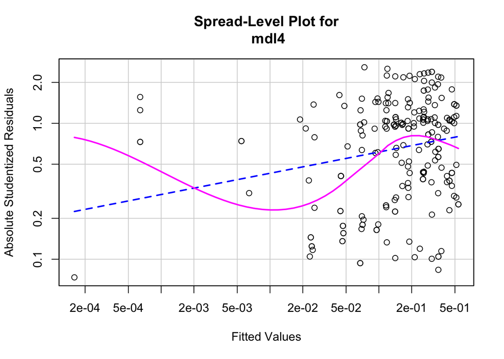

```
##
## Suggested power transformation:  0.8436193
```

```r
spreadLevelPlot(mdl4)
```

```r
summary(mdl4)
```

```
##
## Call:
## lm(formula = beauty ~ age + eval, data = filteredData_s)
##
## Residuals:
##     Min      1Q  Median      3Q     Max
## -1.7571 -0.5851 -0.0902  0.4516  1.8964
##
## Coefficients:
##              Estimate Standardized Std. Error t value Pr(>|t|)
## (Intercept)  0.207713     0.000000   0.312078   0.666  0.50602
## age         -0.023534    -0.294424   0.003524  -6.678 7.07e-11 ***
## eval         0.230520     0.162303   0.062618   3.681  0.00026 ***
## ---
## Signif. codes:  0 '***' 0.001 '**' 0.01 '*' 0.05 '.' 0.1 ' ' 1
##
## Residual standard error: 0.7411 on 455 degrees of freedom
## Multiple R-squared:  0.1183, Adjusted R-squared:  0.1144
## F-statistic: 30.52 on 2 and 455 DF,  p-value: 3.637e-13
```

Так как AIC критерий уменьшился при отсутствии student, мы его убрали, но вновь появилась гетероскедастичность, тогда возможно дело в выбросах, попробуем их убрать.

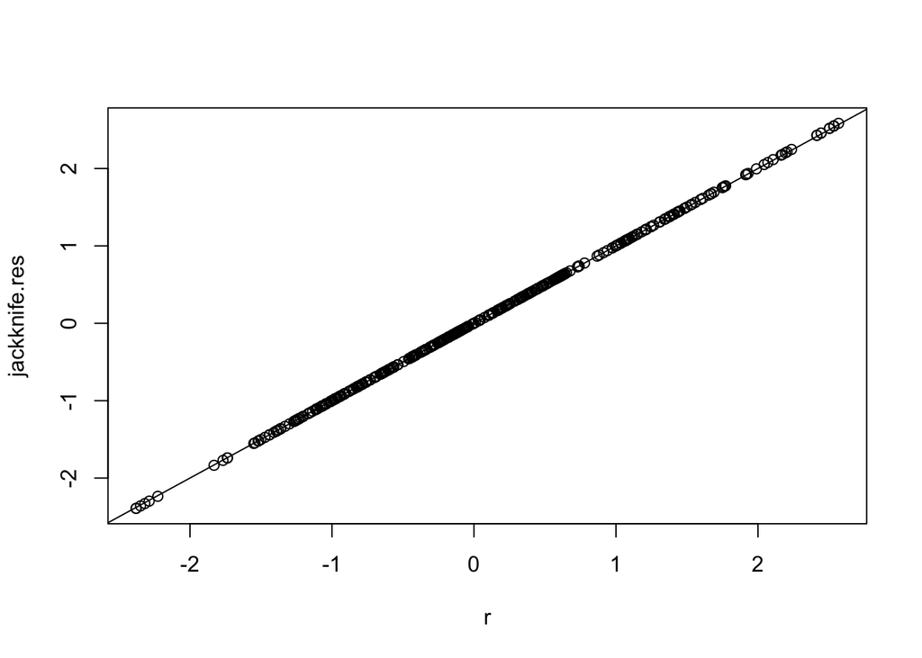

```r
r <- stdres(mdl4) #The standardized residuals. These are normalized to unit variance, fitted including the current data point.
jackknife.res <- studres(mdl4) #deleted residuals (аналогично r, но без привязки к текущей точке)
plot(jackknife.res ~ r)
abline(coef = c(0,1))
```

```r
d1 <- cooks.distance(mdl4)
o <- cbind(filteredData_s, d1, r, jackknife.res)
osorted <- o[order(-d1),]
head(osorted)
```

|  | X | minority | age | gender | credits | beauty | eval | division | native | tenure | students | allstudents | prof | d1 | r | jackknife.res |
| --- | --- | --- | --- | --- | --- | --- | --- | --- | --- | --- | --- | --- | --- | --- | --- | --- |
| 429 | 429 | no | 58 | male | more | 1.774334 | 5.0 | lower | yes | no | 3.044522 | 3.044522 | 85 | 0.02357563 | 2.414998 | 2.427953 |
| 433 | 433 | no | 58 | male | more | 1.774334 | 5.0 | lower | yes | no | 2.397895 | 2.564949 | 85 | 0.02357563 | 2.414998 | 2.427953 |
| 430 | 430 | no | 58 | male | more | 1.774334 | 4.9 | lower | yes | no | 2.890372 | 3.044522 | 85 | 0.02128141 | 2.444546 | 2.458054 |
| 435 | 435 | no | 58 | male | more | 1.774334 | 4.9 | lower | yes | no | 2.772589 | 2.833213 | 85 | 0.02128141 | 2.444546 | 2.458054 |
| 85 | 85 | no | 58 | male | more | 1.774334 | 4.7 | lower | yes | no | 2.772589 | 2.833213 | 85 | 0.01723304 | 2.504062 | 2.518724 |
| 323 | 323 | no | 34 | female | more | -1.450494 | 3.4 | lower | yes | yes | 3.828641 | 4.382027 | 54 | 0.01619506 | -2.226220 | -2.235983 |

```r
#Смотрим на расстояния Кука
o[d1 > 4*mean(d1),]
```

|  | X | minority | age | gender | credits | beauty | eval | division | native | tenure | students | allstudents | prof | d1 | r | jackknife.res |
| --- | --- | --- | --- | --- | --- | --- | --- | --- | --- | --- | --- | --- | --- | --- | --- | --- |
| 22 | 22 | yes | 29 | female | more | -0.8487269 | 3.3 | upper | no | yes | 2.944439 | 3.258097 | 22 | 0.011788855 | -1.5424046 | -1.544752 |
| 25 | 25 | no | 34 | female | more | 1.7755170 | 4.6 | upper | yes | yes | 2.995732 | 3.258097 | 25 | 0.009599978 | 1.7724364 | 1.776632 |
| 43 | 43 | no | 39 | female | more | 1.9700230 | 3.4 | lower | yes | no | 3.091042 | 3.178054 | 43 | 0.015271154 | 2.5677404 | 2.583705 |
| 54 | 54 | no | 34 | female | more | -1.4504940 | 3.8 | lower | yes | yes | 3.988984 | 4.510860 | 54 | 0.013359793 | -2.3482959 | -2.360059 |
| 68 | 68 | no | 60 | male | more | -1.4229190 | 2.2 | upper | yes | yes | 3.135494 | 3.465736 | 68 | 0.009208020 | -0.9928935 | -0.992878 |
| 85 | 85 | no | 58 | male | more | 1.7743340 | 4.7 | lower | yes | no | 2.772589 | 2.833213 | 85 | 0.017233037 | 2.5040618 | 2.518724 |
| 86 | 86 | no | 42 | male | more | 1.7731510 | 4.9 | lower | yes | yes | 2.708050 | 2.890372 | 86 | 0.010930276 | 1.9303424 | 1.936164 |
| 89 | 89 | yes | 35 | female | more | 1.7694520 | 3.4 | lower | yes | yes | 4.094345 | 4.564348 | 89 | 0.014358601 | 2.1710554 | 2.179989 |
| 210 | 210 | no | 34 | female | more | 1.7755170 | 3.9 | upper | yes | yes | 3.496508 | 3.688879 | 25 | 0.009228616 | 1.9890276 | 1.995535 |
| 279 | 279 | no | 39 | female | more | 1.9700230 | 4.7 | upper | yes | no | 2.890372 | 3.135494 | 43 | 0.011686350 | 2.1625579 | 2.171368 |

[output cut: 20 more lines]

```r
#Перестраиваем модель без выбросов
summary(mdln4 <- lm(beauty ~ age + eval, data = filteredData_s[!filteredData_s$X %in% o[d1 > 4*mean(d1),]$X,]))
```

```
##
## Call:
## lm(formula = beauty ~ age + eval, data = filteredData_s[!filteredData_s$X %in%
##     o[d1 > 4 * mean(d1), ]$X, ])
##
## Residuals:
##      Min       1Q   Median       3Q      Max
## -1.28258 -0.52810 -0.05996  0.41751  1.68219
##
## Coefficients:
##              Estimate Std. Error t value Pr(>|t|)
## (Intercept)  0.691227   0.292427   2.364   0.0185 *
## age         -0.025955   0.003196  -8.122 5.03e-15 ***
## eval         0.125603   0.057179   2.197   0.0286 *
## ---
## Signif. codes:  0 '***' 0.001 '**' 0.01 '*' 0.05 '.' 0.1 ' ' 1
##
## Residual standard error: 0.633 on 425 degrees of freedom
## Multiple R-squared:  0.1515, Adjusted R-squared:  0.1475
## F-statistic: 37.94 on 2 and 425 DF,  p-value: 6.901e-16
```

```r
summary(mdln4<-lm.beta(lm(beauty ~ age + eval, data = filteredData_s[!filteredData_s$X %in% o[d1 > 4*mean(d1),]$X,])))
```

```
##
## Call:
## lm(formula = beauty ~ age + eval, data = filteredData_s[!filteredData_s$X %in%
##     o[d1 > 4 * mean(d1), ]$X, ])
##
## Residuals:
##      Min       1Q   Median       3Q      Max
## -1.28258 -0.52810 -0.05996  0.41751  1.68219
##
## Coefficients:
##              Estimate Standardized Std. Error t value Pr(>|t|)
## (Intercept)  0.691227     0.000000   0.292427   2.364   0.0185 *
## age         -0.025955    -0.365313   0.003196  -8.122 5.03e-15 ***
## eval         0.125603     0.098804   0.057179   2.197   0.0286 *
## ---
## Signif. codes:  0 '***' 0.001 '**' 0.01 '*' 0.05 '.' 0.1 ' ' 1
##
## Residual standard error: 0.633 on 425 degrees of freedom
## Multiple R-squared:  0.1515, Adjusted R-squared:  0.1475
## F-statistic: 37.94 on 2 and 425 DF,  p-value: 6.901e-16
```

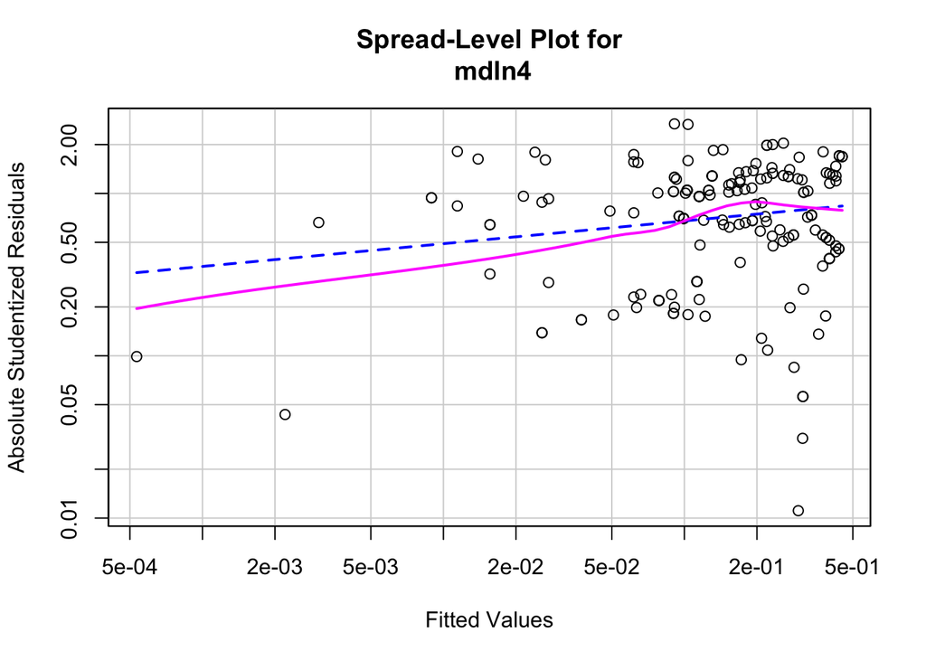

```
##
## Suggested power transformation:  0.8598753
```

```r
spreadLevelPlot(mdln4)
```

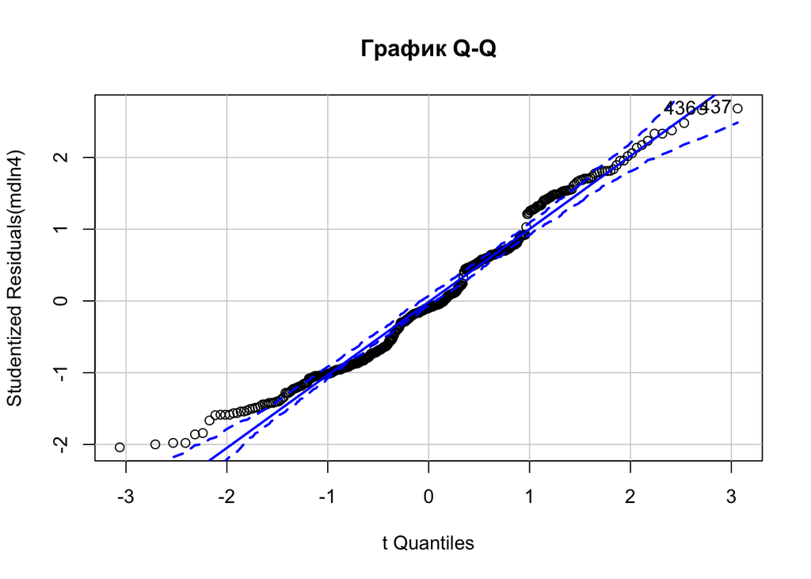

```
## 436 437
## 404 405
```

```r
qqPlot(mdln4, labels = row.names(states), simulate = TRUE, main = 'График Q-Q')
```

С убранными “выбросами” *p-values* стали меньше 6.901e-16, а также возросло значение *Multiple R-squared*
$$R^2 = 1- \displaystyle{{min_{\hat\eta}\mathbf{E}(\eta - \hat\eta)^2}\over{\mathbf{D}\eta}}.$$

Значимость модели:

```r
anova(mdln4)
```

|  | Df | Sum Sq | Mean Sq | F value | Pr(>F) |
| --- | --- | --- | --- | --- | --- |
| age | 1 | 28.467788 | 28.4677882 | 71.056447 | 5.443253e-16 |
| eval | 1 | 1.933233 | 1.9332327 | 4.825406 | 2.858255e-02 |
| Residuals | 425 | 170.270406 | 0.4006362 | NA | NA |

```r
summary(mdl4)
```

```
##
## Call:
## lm(formula = beauty ~ age + eval, data = filteredData_s)
##
## Residuals:
##     Min      1Q  Median      3Q     Max
## -1.7571 -0.5851 -0.0902  0.4516  1.8964
##
## Coefficients:
##              Estimate Standardized Std. Error t value Pr(>|t|)
## (Intercept)  0.207713     0.000000   0.312078   0.666  0.50602
## age         -0.023534    -0.294424   0.003524  -6.678 7.07e-11 ***
## eval         0.230520     0.162303   0.062618   3.681  0.00026 ***
## ---
## Signif. codes:  0 '***' 0.001 '**' 0.01 '*' 0.05 '.' 0.1 ' ' 1
##
## Residual standard error: 0.7411 on 455 degrees of freedom
## Multiple R-squared:  0.1183, Adjusted R-squared:  0.1144
## F-statistic: 30.52 on 2 and 455 DF,  p-value: 3.637e-13
```

Модель на основе переменных age и eval значима, так как $p-value<0.05$

Попробуем сделать предсказание с 95% доверительным интервалом

```r
newdata = data.frame(age=c(50, 50, 30, 20), eval=c(4, 5, 5, 5))
predict(mdln4,newdata, interval = "confidence", level = 0.95)
```

```
##           fit        lwr         upr
## 1 -0.10412193 -0.1647920 -0.04345185
## 2  0.02148118 -0.1076073  0.15056963
## 3  0.54058559  0.3756710  0.70550024
## 4  0.80013780  0.5896621  1.01061355
```

```r
predict(mdln4,newdata, interval = "prediction")
```

```
##           fit        lwr      upr
## 1 -0.10412193 -1.3497189 1.141475
## 2  0.02148118 -1.2293164 1.272279
## 3  0.54058559 -0.7144155 1.795587
## 4  0.80013780 -0.4616589 2.061934
```

Видим, что при одинаковом возрасте и разных оценках, модель показывает, что красивее преподаватель с более высокой оценкой. А при разных возрастах и одинаковых оценках, предпочтение отдаётся более молодому преподавателю.